# Multinomial logit models with INLA

Francesco Serafini (serafini314@gmail.com)

April 2018, revised Nov 2019

## Abstract

The aim of this tutorial is to show how to perform Bayesian analysis in the case of multinomial data. Every time we have to model a situation with mutually exclusive alternatives then a multinomial likelihood arises. Think of a customer that have to choose among different brands for the same product or to the result of a football match (win, draw, loss) or to count data with a fixed sum. All these situations may be modeled with a multinomial model. The multinomial probabilities are a ratio of a function of parameters to a sum of those functions. From the complex functional form of this likelihood derives the difficulties on maximizing it. These difficulties become bigger if we introduce random effects in the model.

In this tutorial, we will use the Multinomial-Poisson transform (Baker (1994)) to transform the multinomial likelihood into a Poisson likelihood with additional parameters. The use of this transformation ensures us the same estimates and asymptotic variances. This technique is also called the Poisson Trick. Given that we can use the INLA (Håvard Rue, Martino, and Chopin (2009)) package to deal with Poisson variables. The key advantage of using INLA is that we can introduce complex random effects in the model paying a “discounted price” for them. Chen and Kuo (2001) and Lee, Green, and Ryan (2017) applied the Poisson Trick to Multinomial data studying the Yogurt Data (first introduced by Janin, Vilcassim, and Chintagunta (1994)) but both of them use SAS and no random effects are included in the models.

There exist packages to work directly with multinomial data, like mlogit (Croissant (2013)) and nnet (Venables and Ripley (2013)) but even in this case is difficult to introduce a random effect in the model.

The tutorial is organized in two main part: the first one is theoretical and talks about the multinomial logit model and the Poisson trick. The second part is more practical and talks about the parameters specification and the different models that we can implement in INLA. This part has the purpose of laying the foundations of a long-lasting friendship between the reader and INLA. All the steps needed to be friends are retraced: from the first sight (simplest model) to help each other in struggling situations (continuous space models, here INLA really helps us). The section on multinomial logit model and the multinomial data is taken by (Croissant et al. (2012)) given the clarity and elegance of his illustration. To make the explanation as clear as possible and to convince the reader of the effectiveness of this approach we will use simulated data. In this way, the true value of the parameters is known and we can check how well we are able to retrieve it. The code is provided and explained as well. In the end, we will report the results of our technique on the famous Yogurt Data.

## Theoretical part

### On the Multinomial logit model

The multinomial logit model arises naturally when we have to model discrete choices. The sample unit has to make a choice between mutually exclusive alternatives. Let see how to build this kind of models. Suppose a customer has to choose between three brands of a certain good. We can define an index of satisfaction $V_{ij}$ for customer $i$ with respect to brand $j$. Assume that $V_{ij}$ is a linear function of some covariates. The situation for $i$-th customer is:

$$\begin{cases}
V_{i1} = \beta_0 + \beta_1x_{i1} + \beta_2z_{i1} \\
\\
V_{i2} = \beta_0 + \beta_1x_{i2} + \beta_2z_{i2} \\
\\
V_{i3} = \beta_0 + \beta_1x_{i3} + \beta_2z_{i3}
\end{cases}$$

Now we have to transform these satisfaction indexes into probabilities. Considering that the probability of choosing alternative $j$ should increase with $V_{ij}$ then the multinomial logit model is obtained by considering

$$P_{ij} = \frac{g_{ij}(\boldsymbol\beta)}{G_i(\boldsymbol\beta)}$$
Where $\boldsymbol\beta = \{\beta_0, \beta_1, \beta_2\}$ and

$$g_{ij}(\boldsymbol\beta) = \exp V_{ij} \quad \quad G_i(\boldsymbol\beta)
= \sum_{j =1}^3 g_{ij}(\boldsymbol\beta)$$

This specification of $P_{ij}$ ensures that the obtained probabilities are proper. Once fitted, this model can be seen at two levels: *individual* and *aggregate*.

On the *individual* level we can study how the covariates influence the choice of the specific customer and given new data make prediction relative to the single unit.

On the other hand, at the *aggregate* level, the estimated probabilities can be seen as market shares and study how these shares change varying the covariates could be a useful tool for brand market policies.

### On the Poisson Trick

For the sake of coherence, we adopt the same notation used in the original paper on the Multinomial-Poisson transformation (Baker (1994)). Let $\textbf{Y}_i = \{Y_{i1},...,Y_{ij},...\}$, for $i = 1,...,I$ and $j \in J_i$, be a vector of random variables with realization $\textbf{y}_i = \{y_{i1},...,y_{ij},...\}$. The subscript $i$ represents the sample unit and $j$ represents the alternatives. We assume that $\textbf{Y}_i$ follows a multinomial distribution with parameters proportional to $\{ g_{ij} ( \boldsymbol{\beta} ), j \in J_i \}$. Where $g_{ij}(\boldsymbol{\beta})$ is a regression function like the one seen in the previous section. To lighten the notation we omit the dependence from the covariates. The goal is to estimate the regression parameter $\boldsymbol{\beta}$. The likelihood is:

$$\begin{align*}
L_M(\boldsymbol{\beta}) = \prod_{i = 1}^I N_i ! \prod_{j \in J_i}
\frac{1}{y_{ij}!}\left(
\frac{g_{ij}(\boldsymbol\beta)}{G_i(\boldsymbol\beta)} \right)^{y_{ij}}
\end{align*}$$

Where

$$G_i(\boldsymbol\beta) = \sum_{j = 1}^{J_i} g_{ij}(\boldsymbol\beta) \, ,
\quad N_i = \sum_{j = 1}^{J_i} y_{ij}$$

The problems in dealing with this likelihood come from the presence of $G_i(\boldsymbol\beta)$ which makes the use of logarithm pointless. The idea behind the Multinomial-Poisson (MP) transformation is to treat this set of functions as additional parameters to be estimated. The MP transformation of equation (1) is:

$$\begin{align*}
L_P(\boldsymbol{\beta,\phi}) = \prod_{i = 1}^{I}\prod_{j \in J_i}
(g_{ij}(\boldsymbol\beta)\exp\phi_i
)^{y_{ij}}\exp\{-g_{ij}(\boldsymbol\beta)\exp\phi_i \}
\end{align*}$$

Where $\boldsymbol\phi = \{\phi_1, ...,\phi_I\}$ is the vector of additional parameters to make the transformation work. In fact, considering the logarithm of equation (2), taking the derivative with respect to $\phi_i$ and setting it to zero we obtain the following result:

$$\exp(\phi_i) = \frac{N_i}{G_i(\boldsymbol\beta)}$$

Where $J_i$ is the size of observation $i$. this ensures that $L_P(\phi(\boldsymbol\beta), \boldsymbol\beta) \propto L_M(\boldsymbol\beta)$. On the basis of results in Richards (1961) it follows that the maximum likelihood estimates of $\boldsymbol\beta$ and their asymptotic variances are identical for $L_P(\boldsymbol{\phi, \beta})$ and $L_M(\boldsymbol\beta)$.

The name of the transformation derives from the fact that $L_P(\boldsymbol{\phi, \beta})$ is the likelihood kernel of a vector of Poisson variables

$$Y_{ij} \sim \text{Poisson}\{g_{ij}(\boldsymbol\beta)\exp\phi_i\}, \quad
j \in J_i$$

Notice that this notation is improper because in this case the $Y_{ij}$ are finite and bounded by the size of the multinomial. In a true Poisson model, the sample space is infinite. However, this expression is very useful to memorize the transformation and gives us the idea of what is going on.

Given that INLA is used to perform Bayesian analysis, we usually would have to set a prior on $\phi$. Let’s assume to not have any information and to choose an improper prior for $\phi$, $\pi(\phi) \propto c$. Then, the marginal likelihood for the Poisson surrogate model for a single multinomial observation $Y_{ij}$ is (we will omit subscript i:

$$L_P(\boldsymbol \beta,\phi) =
\prod_{j=1}^{J} (g_{j}(\boldsymbol\beta)\exp\phi
)^{y_{j}}\exp\{-g_{j}(\boldsymbol\beta)\exp\phi \} /y_j !$$

Integrating out $\phi$ we obtain

$$\begin{align*}
L_P(\boldsymbol \beta) & = \int_{-\infty}^{+\infty} \left(
\prod_{j=1}^{J} \{g_{j}(\boldsymbol\beta)\exp\phi
\}^{y_{j}}\exp\{-g_{j}(\boldsymbol\beta)\exp\phi \} /y_{j} ! \right)
\pi(\phi) d\phi \\
\\
& = \prod_{j=1}^{J} \left(
\frac{\{g_{j}(\boldsymbol\beta)\}^{y_{j}}}{y_j!}\right)
\int_{-\infty}^{+\infty} \phi ^{J}\exp\{-G(\boldsymbol\beta)\exp\phi \}
d\phi \\
\\
& = \prod_{j=1}^{J} \left(
\frac{g_{j}(\boldsymbol\beta)^{y_{j}}}{y_j!}\right)
\frac{\Gamma(N)}{G(\boldsymbol \beta)^J} \\
\\
& = (N-1)!\prod_{j=1}^{J} \frac{1}{y_{ij!}} \left(
\frac{g_{j}(\boldsymbol\beta)}{G(\boldsymbol \beta)}\right)^{y_{ij}}
\end{align*}$$

Where, from the second passage we omit the constant $c$ from the calculations. The obtained expression is very close to the likelihood of a Multinomial distribution.

$$\frac{L_P(\boldsymbol\beta)N}{c} \approx L_M(\boldsymbol \beta)$$

Here, we provide a small example just to prove to the reader the value of this approximation, we are going to use a binomial model that are the most simple version of multinomial. The transformation will seem obscure at the beginning, however, the goal here is to show that the likelihood actually matches and to check the correctness of the correction factor.

First of all generate a vector of proababilities and a vector of sizes.

```r
# number of observations
n = 10

x = rnorm(n, sd = 1)
eta = 1 + x
prob = exp(eta)/(1+exp(eta))

# Sizes
Ntrials = sample(100:1000, n, replace=TRUE)

# Observations
y = rbinom(n, size=Ntrials, prob = prob)
```

Then we set the variance of the prior of $\phi$, in particular we specify a value for the log precision.

```r
lprec = 25
```

This imply a standard deviation of

```r
sqrt(1/exp(-lprec))
```

```
## [1] 268337.3
```

Then, we run the INLA model

```r
mult.model = inla(y ~ -1 + intercept + x,
         data = data.frame(y, x, Ntrials, intercept = rep(1, n)),
         family = "binomial", Ntrials = Ntrials,
         control.predictor = list(hyper = list(prec = list(initial = lprec))),
         control.inla = list(int.strategy="eb"))
```

Now, we have to replicate it with a surrogate Poisson model. The $n$ binomial observations become $2*n$ Poisson observation, consisting of $y_i$ and $N_i - y_i$.

```r
# initialize
Y = intercept = xx = c()
for(i in 1:n) {
    # corresponding vector of observations
    Y = c(Y, c(y[i], Ntrials[i] - y[i]))
    # corresponding covariates
    xx = c(xx, c(x[i], 0))
    intercept = c(intercept, c(1, 0))
}
```

Then, we have to create a vector representing $\boldsymbol \phi$ which assume a different value for each binomial observations

```r
phi = rep(1:n, each=2)
```

Now, we can fit the Poisson model

```r
pois.model = inla(Y ~ -1
          + intercept
          + f(phi, model="iid",
              hyper = list(prec = list(initial = -lprec, fixed=TRUE)))
          + xx,
          family="poisson",
          data = data.frame(Y, xx, phi , intercept),
          control.predictor = list(hyper = list(prec = list(initial = lprec))),
          control.inla = list(int.strategy="eb"))
```

The correction factor for the log-likelihood for each binomial observation will be the sum of $\log(N_i)$ and the logarithm of the flat prior.

```r
corr.factor = - sum(dnorm(pois.model$summary.random$phi$mode,
                          sd = sqrt(1/exp(-lprec)), log=TRUE)) + sum(log(Ntrials))
print(mult.model$mlik)
```

```
##                                            [,1]
## log marginal-likelihood (integration) -46.22204
## log marginal-likelihood (Gaussian)    -46.22204
```

```r
print(pois.model$mlik + corr.factor)
```

```
##                                            [,1]
## log marginal-likelihood (integration) -46.22405
## log marginal-likelihood (Gaussian)    -46.22405
```

## Practical Part

Before going through this tutorial be sure to have the following packages installed

```r
library(Ecdat)
library(deldir)
library(sp)
library(sf)
library(mvtnorm)
library(gridExtra)
library(mlogit)
```

### On the Multinomial Data and Model Parameters

In this section, we illustrate the shape that our data has to have in order to work with INLA properly. This shape is different from the ones used in the literature, therefore, we strongly recommend the reader to read this part carefully. The two dataset shapes known in literature are the *wide* format and the *long* format. More detail on Croissant et al. (2012). We will use a mix of these two, the shape of a variable depends on its nature. The types of variable that we could encounter will be listed and explained in a minute. Before of that we want to be sure that the structure of the data is clear.

As we said before the Multinomial model explains choice situations; in these situations there is an individual which choose between mutually exclusive alternatives. This structure is reflected in the data that is characterized by three indexes:

- the alternative
- the choice situation
- the individual

The last one is relevant only if we have repeated observation for the same unit. We will not study this kind of situations in the tutorial. So we have two indexes to take into account, one for the alternative and one for the choice situation.  
While working with Multinomial logit models, there exist three kinds of variables:

- **alternative specific** variables $x_{ij}$ with a **generic** coefficient $\beta$. These kind of variables are relative to the alternative and could change for each choice situation. The coefficient is generic: it is not supposed to depend on the alternative. Think to a transport mode situation; spending one euro in car or train is the same, then, we can consider the price as an alternative specific variable with a generic coefficient
- **alternative specific** variables $w_{ij}$ with an **alternative specific** coefficient $\delta_j$. The difference between this category and the previous lies in the coefficient. For these variables, the coefficient depends on the alternative. Continue with the transport mode example; one hour more of travel time has a different impact if spent in a car or in a train. Then, it is reasonable to consider the travel time as alternative specific with an alternative specific coefficient
- **individual specific** variables $z_{i}$ with an **alternative specific** coefficient $\gamma_j$. These variables are relative only to the individual and they have the same value for all the alternatives. The coefficient has to be alternative specific for reason that will see soon. Finishing with the transport mode example we can think of the income of the individual; this variable is clearly related only to the individual.

In the example that we will use from now on there are all these kind of variables. The model that we are considering is the following:

$$V_{ij} = \beta x_{ij} + \delta_j w_{ij} + \gamma_j z_i$$

The model may have an intercept, we choose to omit it just to lighten the formulas. Notice that to model the choice of one alternative over the others we will look only on the differences between satisfaction values. Satisfaction is ordinal. Moreover, given the construction of the multinomial logit model, differences in satisfaction stand for ratio on probabilities. Let us write down these differences:

$$V_{ij} - V_{ik} = \beta(x_{ij} - x_{ik}) + (\delta_jw_{ij} -
\delta_kw_{ik}) + z_i(\gamma_j - \gamma_k)$$
Focusing on $z_i$: if the $\gamma$ is not alternative specific the contribution of this covariate would disappear in the differentiation. Furthermore, only difference $\gamma$’s may be identified. We will back to this point later.

### Data structure

Now we are ready to start with our example. We will work with a multinomial model with three alternatives: A, B, and C. The covariates are also three; one per category. We consider a small data set of $500$ data points. The size of the multinomial will be variable and we will study the effect of this parameter on the posterior estimates. Declare the parameters and the covariates:

```r
beta = -0.3
deltas = c(1, 4, 3)
gammas = c(0.3, 0.2, 0.4)
param = c(beta, deltas, gammas)
n = 500

set.seed(123)
# alternative specific with generic coefficient beta
X.A = rnorm(n, mean = 30, sd = 2.5)
X.B = rnorm(n, mean = 35, sd = 3.5)
X.C = rnorm(n, mean = 40, sd = 1)

# alternative specific with alternative specific coefficient delta
W.A = abs(rnorm(n, mean = 1))
W.B = abs(rnorm(n, mean = 1))
W.C = abs(rnorm(n, mean = 1))

# individual specific with alternative specific coefficient gamma
Z = rnorm(n, 20, 3)
```

As first example we don’t consider any random effect. We write a function of the size $N$ of the multinomial to generate the sample.

```r
Multinom.sample = function(N){
  Y = matrix(NA, ncol = 3, nrow = n)
  for(i in 1:n){
    V.A = beta*X.A[i] + deltas[1]*W.A[i] + gammas[1]*Z[i]
    V.B = beta*X.B[i] + deltas[2]*W.B[i] + gammas[2]*Z[i]
    V.C = beta*X.C[i] + deltas[3]*W.C[i] + gammas[3]*Z[i]

    probs = c(V.A, V.B, V.C)
    probs = exp(probs)/sum(exp(probs))
    samp = rmultinom(1, N, prob = probs)

    Y[i,] = as.vector(samp)
  }
  colnames(Y ) = c("Y.A", "Y.B", "Y.C")
  return(Y)
}
```

Take a look of what it produces.

```r
head(Multinom.sample(1), 5)
```

```
##      Y.A Y.B Y.C
## [1,]   0   0   1
## [2,]   0   1   0
## [3,]   0   0   1
## [4,]   0   1   0
## [5,]   0   0   1
```

```r
head(Multinom.sample(100), 5)
```

```
##      Y.A Y.B Y.C
## [1,]  53  13  34
## [2,]   8  17  75
## [3,]  39   7  54
## [4,]   3  96   1
## [5,]   0   1  99
```

Once we have data we have to build the data set to give to INLA. The dataset will have $n*3$ rows, one for each choice alternative in each choice situation. Now we have to add the covariates and this is the tricky part. The structure of each covariate depends on its type, fortunately, there are only three types and two of them have the same structure. For an **alternative specific** variable with a generic coefficient and for an **individual specific** variable we just use the long format. For alternative specific, each row contain just the value of the variable referred to the corresponding alternative; for the individual specific the value is repeated along the alternatives. For an **alternative specific** with an alternative coefficient, we need three columns, one for each alternative (like the wide format) and $n*3$ rows (like the long format). This is the mixed structure. Each column will have the value of the covariate for the corresponding alternative and zeros for the others. The complicated part is done but the data construction is not finished yet. We need two more columns. An index column representing the **choice situation**, this column will be our additional parameter $\phi$. The last column is another index column representing the **choice alternatives**. We hope the code will clarify what it is hazy to the reader. The following function takes as input a data frame in wide format and transforms it into the desired structure.

```r
Y = Multinom.sample(1)
df = data.frame(cbind(Y, X.A, X.B, X.C, W.A, W.B, W.C, Z))

Data.structure = function(df){
  Data = matrix(NA, ncol = 8, nrow = n*3)
  for(i in 1:n){
    # simulated variable
    Data[((i-1)*3+1):(i*3), 1] = c(df$Y.A[i], df$Y.B[i], df$Y.C[i])
    # alternative specific with generic coeff
    Data[((i-1)*3+1):(i*3), 2] = c(df$X.A[i], df$X.B[i], df$X.C[i])
    # alternative specific with alternative coeff
    Data[((i-1)*3+1):(i*3), 3:5] = diag(c(df$W.A[i], df$W.B[i], df$W.C[i]))
    # individual specific with alternative coeff
    Data[((i-1)*3+1):(i*3), 6] = rep(df$Z[i],3)
    # choice situation index
    Data[((i-1)*3+1):(i*3), 7] = rep(i,3)
    # choice alternative index
    Data[((i-1)*3+1):(i*3), 8] = c(1, 2, 3)
  }
  Data = data.frame(Data)
  names(Data) = c('Y', "X","W.A","W.B","W.C","Z",'phi','alt.idx')
  return(Data)
}

round(head(Data.structure(df)),3)
```

```
##   Y      X   W.A   W.B   W.C      Z phi alt.idx
## 1 1 28.599 0.179 0.000 0.000 19.549   1       1
## 2 0 32.893 0.000 0.488 0.000 19.549   1       2
## 3 0 39.004 0.000 0.000 0.321 19.549   1       3
## 4 0 29.425 0.693 0.000 0.000 19.017   2       1
## 5 0 31.522 0.000 1.237 0.000 19.017   2       2
## 6 1 38.960 0.000 0.000 1.574 19.017   2       3
```

### A Simple Model

Once we have the data, we can fit our first model, without random effect and intercept. First of all, we need to build a formula representing our model. We remember to the reader that the model at hand is the following:

$$Y_{ij} \sim \text{Poisson}(\lambda_{ij})$$
Where
$$\log(\lambda_{ij}) = \phi_i + \beta x_{ij} + \delta_{ij}w_{ij} +
\gamma_j z_i$$

The corresponding formula is:

```r
formula = Y ~ -1 + X + W.A + W.B + W.C +
  f(phi, initial = -10, fixed = T) +
  f(alt.idx, Z, fixed = T, constr = T)
```

Let us explain it. The $-1$, in the beginning, means that we are not considering an intercept. Again, the way in which a variable is declared depends on his type. For the alternative specific variable, we just declare them as they are, without any particular adjustments. The choice situation index variable is declared as a random effect to speed up the code. The individual specific variable is also defined as a random effect. In this way, we can add to the model a sum up to zero constraint on the $\gamma$’s imposing $\texttt{constr = T}$.  
As we said before we may identify only the differences between $\gamma$’s, that gives rise to a system of two equation (one for each difference) in three unknowns. In order to have a unique solution, we need to consider an additional constraint. The only thing missing is to fit the model, if not specified INLA considers a diffuse prior for the parameters. We consider $N = 1$

```r
Data = Data.structure(df)
model = inla(formula, data = Data, family = 'Poisson',
    control.inla=list(int.strategy="eb"))
```

Take a look of what we get

```r
result = rbind(model$summary.fixed[1:5], model$summary.random$alt.idx[2:6])
result = cbind(result, true = param)
row.names(result) = c("beta","delta.A","delta.B","delta.C","gamma.A","gamma.B","gamma.C" )
round(result,3)
```

```
##           mean    sd 0.025quant 0.5quant 0.975quant true
## beta    -0.322 0.039     -0.399   -0.322     -0.245 -0.3
## delta.A  0.800 0.162      0.482    0.800      1.118  1.0
## delta.B  4.404 0.393      3.633    4.404      5.175  4.0
## delta.C  3.004 0.252      2.511    3.004      3.497  3.0
## gamma.A  0.010 0.013     -0.015    0.010      0.035  0.3
## gamma.B -0.126 0.017     -0.160   -0.126     -0.092  0.2
## gamma.C  0.116 0.015      0.086    0.116      0.146  0.4
```

As we can see the estimates for the $\beta$ and $\delta$’s are fine. Instead, the estimates for $\gamma$’s are pretty bad. But, let us look at the difference between them

```r
diff.result =
  cbind("0.025quant"= diff(model$summary.random$alt.idx$`0.025quant`),
      "0.5quant" = diff(model$summary.random$alt.idx$`0.5quant`),
      "0.975quant" = diff(model$summary.random$alt.idx$`0.975quant`),
      "true" = diff(gammas))
row.names(diff.result) = c("gamma.B - gamma.A", "gamma.C - gamma.B")
round(diff.result,3)
```

```
##                   0.025quant 0.5quant 0.975quant true
## gamma.B - gamma.A     -0.145   -0.136     -0.127 -0.1
## gamma.C - gamma.B      0.247    0.242      0.237  0.2
```

As we said before even if we are not able to estimates the true value of the $\gamma$ parameters we can retrieve their differences.

#### Changing the size

What happens if we change the size of the multinomial? Increasing the size of the multinomial gives us more information about the underlying model. Think about it: having a multinomial distribution of size one implies that $y_{ij} \in \{0,1\}$. Remember that we are treating the observations as they come from a collection of Poisson variables. The Poisson is a model for counts data and having only zeros and ones is not the best situation in which use it. Increasing the size we have a more likely counts data and our estimates are more precise.

To prove that, we run one hundred simulation for each $N \in \{1,100,500,1000\}$. Figure 1 shows the confidence intervals for $\beta$, the results are pretty similar for $\delta$’s. The estimates remain centered on the true value of the parameters and the variance reduces as $N$ increases. The situation is a bit different for the difference between $\gamma$ parameters. In this case, the variance of the posterior is small even for $N = 1$ but the intervals get closer and closer to the true value as $N$ increase as it is shown in Figure 2. The take-home message here is to find a way to have $N$ as large as possible. Think to the customer example, instead of considering each customer as a single unit we could aggregate to some covariate level. For example, knowing where the customer made his choice and aggregate to the shop level could be interesting.

Be careful, *All that glitters is not gold*. In this situation, we know the truth and we are using the true model. Using the wrong model could give us very concentrated results in an unrealistic part of the parameters space. If we are not sure of the model, then, take a small $N$ is better because it ensures more flexible posterior results.

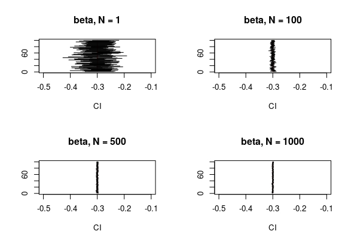

Confidence Interval for beta varying the size parameter N

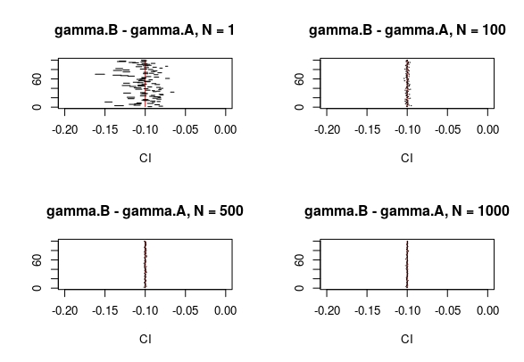

Confidence Interval for the difference between gamma.B and gamma.A varying the size parameter N

### A First Random Effect

Now that we have gain confidence with the multinomial logit model it’s time to add a first, very simple, random effect to the model. As a first example, we consider an independent and identical distributed random effect. The random effect influences only the satisfaction index related to choice $A$, otherwise, considering three random effects would make the model non-identifiable. The model for the other probabilities is exactly the same of the previous section. The modified model is the following:

$$V_{iA} = \beta x_{iA} + \delta_A w_{iA} + \gamma_A z_i + v_i$$
$$v_i \sim N(0, 1) \quad\quad i = 1,...,n$$

In the above formula, $v_i$ represents the random effect that acts in each choice situation, the way in which it influences the choice is independent between different situations. Using the Poisson transformation we are saying that the random effect plays a role only on the observations relative to alternative $A$. In other words the observations for which $\texttt{alt.idx = 1}$. Let us generate the random effect and write a function to generate data following this structure. To have a better fit for this example we consider a multinomial of size $N = 100$

```r
random.effect = rnorm(n)
Multinom.sample.rand = function(N, random.effect){
  Y = matrix(NA, ncol = 3, nrow = n)
  for(i in 1:n){
    V.A = beta*X.A[i] + deltas[1]*W.A[i] + gammas[1]*Z[i] +
      random.effect[i]
    V.B = beta*X.B[i] + deltas[2]*W.B[i] + gammas[2]*Z[i]
    V.C = beta*X.C[i] + deltas[3]*W.C[i] + gammas[3]*Z[i]

    probs = c(V.A, V.B, V.C)
    probs = exp(probs)/sum(exp(probs))
    samp = rmultinom(1, N, prob = probs)

    Y[i,] = as.vector(samp)
  }
  colnames(Y) = c("Y.A", "Y.B", "Y.C")
  return(Y)
}

Y.rand1 = Multinom.sample.rand(100, random.effect)
df.rand1 = data.frame(cbind(Y.rand1, X.A, X.B, X.C, W.A, W.B, W.C, Z))
Data.rand1 = Data.structure(df.rand1)
```

In INLA adding a random effect is simple. We just need an index variable indicating on which observations it acts, the others will be set to $\texttt{NA}$. Then, first step: add an index variable to the data.

```r
rand.idx = rep(NA, n*3)
rand.idx[seq(1,n*3, by = 3)] = seq(1,n)
Data.rand1$rand.idx = rand.idx
round(head(Data.rand1),3)
```

```
##    Y      X   W.A   W.B   W.C      Z phi alt.idx rand.idx
## 1 24 28.599 0.179 0.000 0.000 19.549   1       1        1
## 2 21 32.893 0.000 0.488 0.000 19.549   1       2       NA
## 3 55 39.004 0.000 0.000 0.321 19.549   1       3       NA
## 4  7 29.425 0.693 0.000 0.000 19.017   2       1        2
## 5 14 31.522 0.000 1.237 0.000 19.017   2       2       NA
## 6 79 38.960 0.000 0.000 1.574 19.017   2       3       NA
```

The other thing that we need in INLA to consider a random effect is to specify it in the formula. To do that we use the function $\texttt{f()}$; it takes as inputs the index column that we have created before and the model, equal to $\texttt{iid}$ in this case. In the next sections, we will see that to consider a structured random effect it is sufficient to change the model option.

```r
formula.rand1 = Y ~ -1 + X + W.A + W.B + W.C +
  f(phi, initial = -10, fixed = T) +
  f(alt.idx, Z, fixed = T, constr = T) +
  f(rand.idx, model = "iid")  #random effect
```

Then, just run the $\texttt{inla()}$ function and check the result.

```r
model.rand1 = inla(formula.rand1, data = Data.rand1, family ='Poisson',
    control.inla=list(int.strategy="eb"))
result.rand1 = rbind(model.rand1$summary.fixed[1:5])
result.rand1 = cbind(result.rand1, true = param[1:4])
row.names(result.rand1) = c("beta","delta.A","delta.B","delta.C")
round(result.rand1,3)
```

```
##           mean    sd 0.025quant 0.5quant 0.975quant true
## beta    -0.293 0.006     -0.304   -0.293     -0.282 -0.3
## delta.A  1.051 0.059      0.935    1.051      1.166  1.0
## delta.B  3.948 0.044      3.863    3.948      4.034  4.0
## delta.C  2.969 0.034      2.902    2.969      3.036  3.0
```

```r
diff.result.rand1 =
  cbind("0.025quant"= diff(model.rand1$summary.random$alt.idx$`0.025quant`),
      "0.5quant" = diff(model.rand1$summary.random$alt.idx$`0.5quant`),
      "0.975quant" = diff(model.rand1$summary.random$alt.idx$`0.975quant`),
      "true" = diff(gammas))
row.names(diff.result.rand1) = c("gamma.B - gamma.A", "gamma.C - gamma.B")
round(diff.result.rand1,3)
```

```
##                   0.025quant 0.5quant 0.975quant true
## gamma.B - gamma.A     -0.091   -0.093     -0.095 -0.1
## gamma.C - gamma.B      0.196    0.196      0.196  0.2
```

Regarding the random effect, there are many indexes that we can use to evaluate the estimates. We choose the simplest one and check the accuracy of our estimates calculating the mean square error which is satisfyingly low.

```r
mean((random.effect - model.rand1$summary.random$rand.idx$`0.5quant`)^2)
```

```
## [1] 0.2471006
```

Exactly as before, increasing the size of the multinomial we have better estimates. We run one hundred simulations for each value of size $N \in \{ 1,100,500,1000\}$. The statements that we have done in the previous section are valid also for the random effect estimates. Greater the size better the accuracy. In Figure 3 are reported the box plots of the mean square errors for each value of $N$.

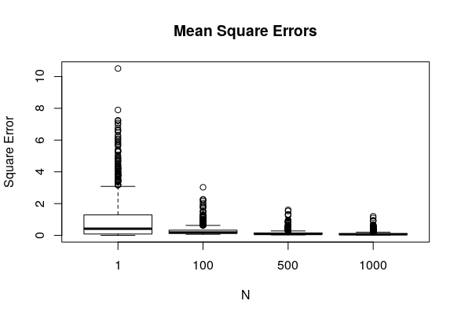

Boxplot of the estimated random effect mean square errors varying the size parameter N

The estimates with $N = 1$ are particularly bad, that’s why there is not enough information to evaluate correctly the random effect and the resulting estimates are almost zero. To make this point clearer in Figure 4 are reported the confidence intervals relative to $20$ samples from the random effect.

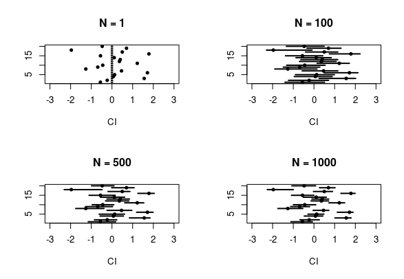

Confidence intervals for a sample of 20 points from the random effect varying the size parameter N

### Time Random Effects

Now that we are a little bit more familiar with INLA (not friends yet), we can go further and add a simple structure to our random effect. Consider one of the easiest and most used structures for random effects: a random walk. This kind of random effects is particularly useful when we have observations repeated in time. For example, we have the choices story of a customer. In this situation we can imagine that these choices are linked together, that exists a connection between adjacent observations. In this situation, we may use a random walk of some order to link the observations. Generate a random walk of order one and the corresponding data.

```r
#  Generate the random effect
random.walk1 = rep(NA, n)
random.walk1[1] = 0
for(i in 2:n){
  random.walk1[i] = rnorm(1, mean = random.walk1[i-1], sd = 0.1)
}

# Generate data
Y.rw1 = Multinom.sample.rand(100, random.walk1)
df.rw1 = data.frame(cbind(Y.rw1, X.A, X.B, X.C, W.A, W.B, W.C, Z))
Data.rw1 = Data.structure(df.rw1)
```

The INLA package needs exactly the same thing of the previous section: an index variable and a $\texttt{f()}$ function. The difference is in that now we have to write $\texttt{model = "rw1"}$ when we specify the formula. This syntax is pretty general in INLA for the random effects. For example, if we want to consider a random walk of order two instead of one, we have to specify $\texttt{model = "rw2"}$. For a complete list of the models just run this command $\texttt{names(inla.models()\$latent)}$. For more details on the use of INLA check (Blangiardo and Cameletti (2015)).

Back to the problem, the index column is the same of the previous section since only the “first” probability is affected by the random effect. The model is the following:

$$V_{itA} = \beta x_{itA} + \delta_A w_{itA} + \gamma_A z_{it} + u_t$$
Where $i$ is an index for the individual, in our example we consider all the observations as relative to the same customer. Subscript $t$ represents the time in which the choice is made and $u_t$ is a random walk of order one such that:
$$u_t|u_{t-1} \sim N(u_{t-1}, \sigma^2_u)$$
Also the syntax to fit the model is exactly the same as before.

```r
rw1.idx = rep(NA, n*3)
rw1.idx[seq(1,n*3, by = 3)] = seq(1,n)
Data.rw1$rw1.idx = rw1.idx

formula.rw1 = Y ~ -1 + X + W.A + W.B + W.C +
  f(phi, initial = -10, fixed = T) +
  f(alt.idx, Z, fixed = T, constr = T) +
  f(rw1.idx, model = "rw1")  #random walk of order 1

model.rw1 = inla(formula.rw1, family = 'poisson', data = Data.rw1,
    control.inla=list(int.strategy="eb"))
```

To check the goodness of our estimate we show the trace plots of the true random walk and the estimated one. In particular to make the curves match we have to subtract the mean from the true random walk. That’s why the model assumes a zero mean random walk and the simulated one has not mean equal to zero. This technicality is relevant only if we know the truth and we have to plot it. As it is shown in Figure 5 the curves match very well.

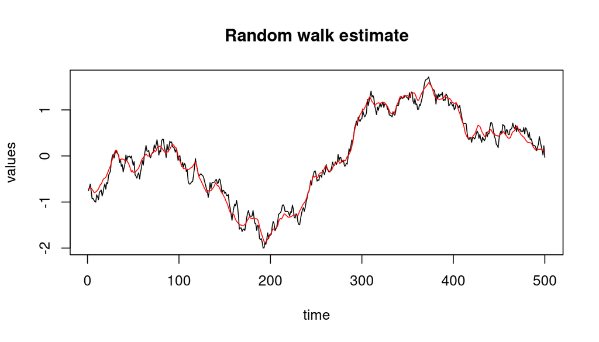

Estimate of a random walk, the black line represents the true one and the red line the estimate

### Discrete Spatial Random effect

Now that the seeds of our INLA-friendship are sowed we can move forward and start talking about spatial random effect. Spatially structured random effects are useful in many situation; take again the customer example and assume that we know the location of each choice situation, where the individual made its choice. This choice could be influenced by some advertising campaign for which we don’t have data. Think of a billboard, only the customers near it may be influenced.

In general, whenever the covariates don’t explain enough the variability of the observations, the observations given the covariates are not independent, then considering a spatial structure may mitigate the problem. Let us start with the discrete case. We have the space that is divided in a certain number of regions (e.g. municipality, cities, countries,…) and each region is influenced and influence only its neighbors. Each data point in a region is subject to the same random effect. To simulate data with this structure we the points locations and a partition of the space. For the locations we just pick $n$ points at random in the set $[0,1]\times[0,1]$.

```r
x.loc = runif(n)
y.loc = runif(n)
loc = cbind("x.loc" = x.loc, "y.loc" = y.loc)
```

For the partition is a little bit more complicated. One way to do that is to select some point at random in $[0,1]\times[0,1]$ and construct the Voronoi Tessellation using these points as centers. We are not going through the details of Voronoi tessellation, for whom is interested more details on De Berg et al. (2000). This is a function to generate a Voronoi polygons given points, it uses functions from the $\texttt{sp}$ (E. J. Pebesma and Bivand (2005)) and $\texttt{deldir}$ (Turner (2017)) libraries.

```r
voronoi.polygons <- function(x) {
  require(deldir)
  if (.hasSlot(x, 'coords')) {
    crds <- x@coords
  } else crds <- x
  z <- deldir(crds[,1], crds[,2])
  w <- tile.list(z)
  polys <- vector(mode='list', length=length(w))
  require(sp)
  for (i in seq(along=polys)) {
    pcrds <- cbind(w[[i]]$x, w[[i]]$y)
    pcrds <- rbind(pcrds, pcrds[1,])
    polys[[i]] <- Polygons(list(Polygon(pcrds)), ID=as.character(i))
  }
  SP <- SpatialPolygons(polys)
  voronoi <- SpatialPolygonsDataFrame(SP,
                                      data=data.frame(x=crds[,1],
                                                      y=crds[,2],
                                                      row.names=sapply(slot(SP, 'polygons'),
                                                                       function(x) slot(x, 'ID'))))
}
```

To generate a partition of the space just pick some random points, be sure that the corners of your study area are included and the above function will generate one region (polygon) for each point. Before move on we would like to give some information on the output of $\texttt{voronoipolygons()}$. This function gives us a SpatialPolygonsDataFrame. This kind of object is very useful when we are dealing with spatial data. Each row of the data frame is related to a region and we can put there whatever we want as a column. How to use it and how to make nice plots will be shown in a while, first of all, let us generate the partition.

```r
# number of regions
n.reg = 50
# corners
boundaries = rbind(c(0,0), c(1,1), c(0,1), c(1,0))
# points
points = rbind(boundaries, cbind(runif(n.reg - 4), runif(n.reg - 4)))
# generate Voronoi polygons
vor = voronoi.polygons(points)
```

Now let us check how many non-empty regions do we have and make the first plot with the Voronoi polygons and the locations.

```r
# Create an ID column for the regions, it will be our index
vor@data$id = seq(1,n.reg)
# Transform the locations in SpatialPoint
pp = SpatialPoints(loc)
# This vector contains the region in which each point is located
id.samples = over(pp,vor)$id
# Check the number of non epty regions
check = as.integer(length(unique(id.samples)))
check
```

```
## [1] 48
```

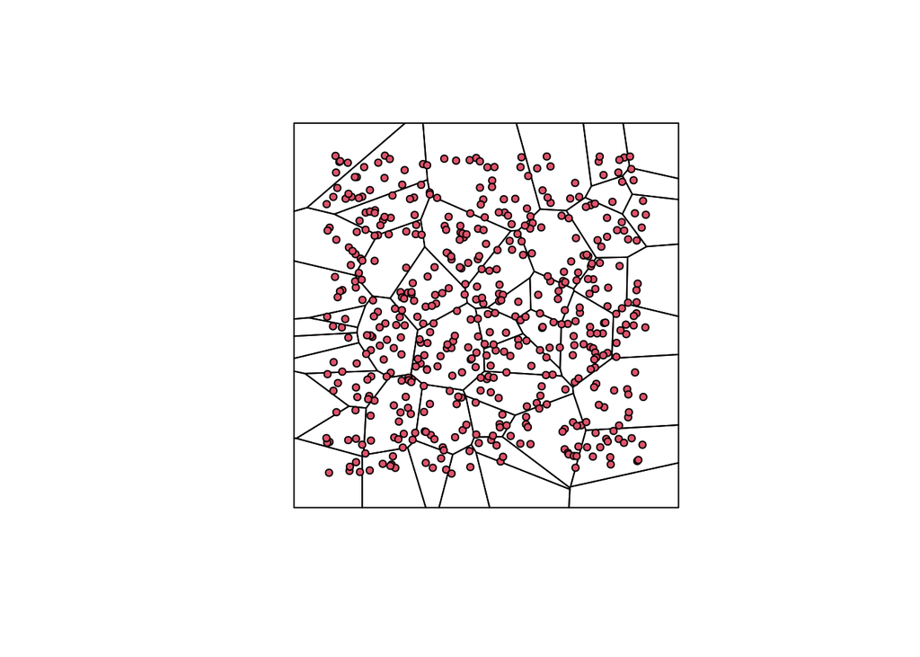

Partition of the region [0,1]x[0,1], each red point correspond to a different location

```r
# plot the partition and the locations
plot(vor)
points(loc, pch = 21, bg = 2, cex = 0.7)
```

Once we have a partition of the space we need to generate a random effect. To take into account the neighbor structure of the partition we choose to use a **Gaussian Markov Random Field**. More details on (Havard Rue and Held (2005)) and (Blangiardo and Cameletti (2015)). Skipping all the theoretical stuff, we need to synthesize the neighbors’ structure; we need the adjacency matrix $A$. With $A$ in the hands, we will generate the random effect from a multivariate Gaussian distribution with a covariance matrix that depends on the adjacency matrix. This model is also called CAR model or iCAR model depending on the specification of the covariance matrix. To calculate the adjacency matrix we use the function `st_touches()` of the package `sf`, E. Pebesma (2018). To sample from the multivariate normal with a given covariance matrix one can use the `rmvnorm()` function of the package `mvtnorm`, Genz and Bretz (2009). When the precision matrix is available, we can use the `inla.qsample()` function in `INLA`. More details on polygons here [Polygons web Page]

```r
# adjacency matrix
ADJ <- as(st_touches(st_as_sf(vor)), "Matrix")
# Unscaled precision matrix
Q_unscaled <- Matrix::Diagonal(n.reg, colSums(ADJ)) - ADJ * 0.99 # CAR
# marginal inverse standard deviation of each random effect component
SD_inv <- Matrix::Diagonal(n.reg, 1.0^-1)
# Std.dev. from the unscaled precision
SD_scale <- Matrix::Diagonal(n.reg, diag(inla.qinv(Q_unscaled))^0.5)
# covariance matrix
prec.matrix <- (SD_inv %*% SD_scale) %*% Q_unscaled %*% (SD_scale %*% SD_inv)
prec.matrix <- (prec.matrix + t(prec.matrix)) / 2
# generate the random effect and add it to the SpatialPolygonDataFrame
vor@data$rand.eff <- as.numeric(inla.qsample(1, prec.matrix, seed = 1234))
```

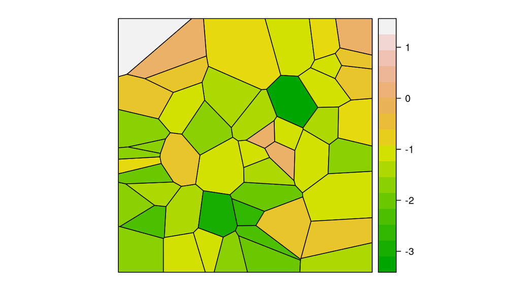

Random effect on the partition

```r
spplot(vor, 'rand.eff', col.regions = terrain.colors(32))
```

We can breathe a sigh of relief, this tricky part about polygons is over. What remains to do is to generate data accordingly to this model, remember, each location in the same region is affected by the same value of the random effect. Then we can use the same function used before to sample from the data, we just need to build the random effect vector in the proper way.

```r
# generate random effect vector
random.effect = vor@data$rand.eff[id.samples]
# generate sample
Y.spatial = Multinom.sample.rand(N = 100, random.effect)
# construct data set
df.spatial = data.frame(cbind(Y.spatial, X.A, X.B, X.C, W.A, W.B, W.C, Z))
Data.spatial = Data.structure(df.spatial)
```

Using the same function to generate data as before means that the spatial random effect influences only the first probability, then we have to build an index column with non zero elements only on the row relative to the first alternative. These elements are the id of the region in which the observation is located. The index column plays the same role of the previous examples: using it as input on the $\texttt{f()}$ function in the formula we specify our spatial random effect. In this situation we set $\texttt{model = "besag"}$ because was him to introduce this model in Besag (1974). The only additional requirements is that we need to specify a neighbors structure in the $\texttt{f()}$ function, it is done using the adjacency matrix setting $\texttt{graph = ADJ}$.

```r
# create and add index column
rand.eff.idx = rep(NA, n*3)
rand.eff.idx[seq(1,n*3, by = 3)] = id.samples
Data.spatial$rand.eff.idx = rand.eff.idx

# Formula
formula.spatial = Y ~ -1 + X + W.A + W.B + W.C +
  f(phi, initial = -10, fixed = T) +
  f(alt.idx, Z, fixed = T, constr = T) +
  f(rand.eff.idx, model = 'besag', graph = ADJ) #spatial random effect

# Fit the model
model.spatial = inla(formula.spatial, family = "poisson", data = Data.spatial,
    control.inla=list(int.strategy="eb"))

# Check the results
result.spatial = cbind(model.spatial$summary.fixed[3:5], true = param[1:4])
row.names(result.spatial) = c("beta","delta.A","delta.B","delta.C")

diff.result.spatial =
  cbind("0.025quant"= diff(model.spatial$summary.random$alt.idx$`0.025quant`),
        "0.5quant" = diff(model.spatial$summary.random$alt.idx$`0.5quant`),
        "0.975quant" = diff(model.spatial$summary.random$alt.idx$`0.975quant`),
        "true" = diff(gammas))
row.names(diff.result.spatial) = c("gamma.B - gamma.A", "gamma.C - gamma.B")

round(rbind(result.spatial, diff.result.spatial),3)
```

```
##                   0.025quant 0.5quant 0.975quant true
## beta                  -0.300   -0.292     -0.283 -0.3
## delta.A                0.923    0.964      1.005  1.0
## delta.B                3.948    4.022      4.096  4.0
## delta.C                2.965    3.019      3.074  3.0
## gamma.B - gamma.A     -0.052   -0.053     -0.053 -0.1
## gamma.C - gamma.B      0.197    0.197      0.197  0.2
```

```r
# compute mean square error
mean((vor@data$rand.eff -
        model.spatial$summary.random$rand.eff.idx$`0.5quant`)^2)
```

```
## [1] 1.516317
```

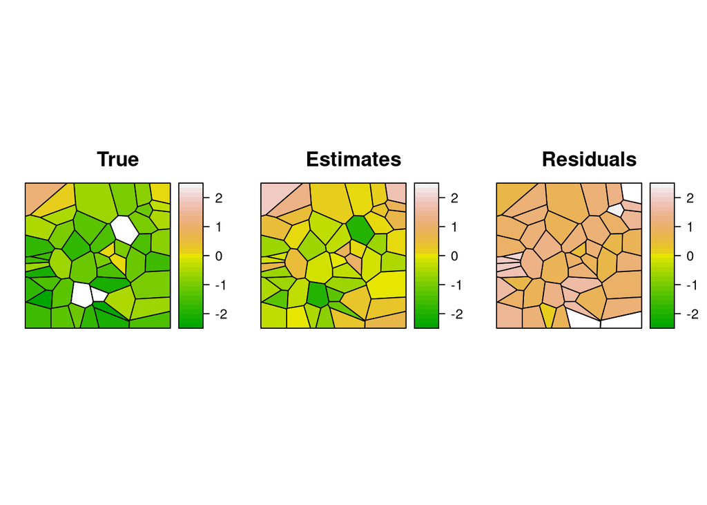

Comparison between the true random effect and the estimated one

```r
# add columns to the SpatialPolygonDataFralme
vor@data$rand.eff.est = model.spatial$summary.random$rand.eff.idx$`0.5quant`
vor@data$residuals = (vor@data$rand.eff-
                        model.spatial$summary.random$rand.eff.idx$`0.5quant`)^2
# plot them
grid.arrange(spplot(vor, 'rand.eff', at = seq(-2.5, 2.5, length.out = 32),
                    col.regions = terrain.colors(32), main = "True"),
             spplot(vor, 'rand.eff.est', at = seq(-2.5,2.5,length.out = 32),
                    col.regions = terrain.colors(32), main = "Estimates"),
             spplot(vor, 'residuals', at = seq(-2.5,2.5,length.out = 32),
                    col.regions = terrain.colors(32), main = "Residuals"),
             nrow = 1)
```

### Continuos spatial random effect

This is the last step to definitively consolidate our friendship with INLA, it’s here that this package shows its full potential and becomes a truly desirable friend. In the previous section we assumed a discrete spatial effect, it means that the effect in a specific region is constant. This approach works well in many situations in which we have an effect related to the county or to the municipality or to the district. What happens if we are working with natural phenomena? In this case, we may suppose that the effect is not constant inside a region or inside a municipality. Think about temperature or air pollution level, in this case, considering the effect derived from these variables as constant inside a region doesn’t seem reasonable. The solution is to consider a continuous random effect (or at least very small regions). We can do that using the so-called SPDE approach. You can find an entire tutorial on this argument on Krainski et al. (2017).

Few words about this: we are considering a **Gaussian random field** with zero mean and Matérn correlation function. Zero mean because the mean is supposed to be modeled by the fixed effects. About the Matérn correlation function, the important thing to have in mind is that it depends on the Euclidean distance between points. This means high correlation for points close to each other and low correlation for far away points. Of course, we cannot deal with something really continuous, otherwise, it will be computationally infisible, but we can deal with something discrete defined on a set of very small regions. Hence, the purpose is to approximate the continuous spatial random effect with a discrete spatial effect (Lindgren, Rue, and Lindström (2011)). Let us start from here: discretization of the study area. We divide the area into small triangles, in each triangle the random effect is supposed to be linear. This operation is called Delaunay Triangulation and the result is a mesh. Even if it seems a complex operation we can build a mesh using INLA in one line of code. The function $\texttt{inla.mesh.2d()}$ requires a set of location and some parameters to guarantee a “nice” triangulation. More details on the parameters and what “nice” means on [Mesh website].

```r
mesh = inla.mesh.2d(loc, max.edge = c(0.02, 0.2), cutoff = 0.02)
```

Let us plot it and check how many triangles we have created for the area of interest. The mesh, being the support for our approximation, more triangles it has, more precise the approximation will be.

```r
mesh$n
```

```
## [1] 2294
```

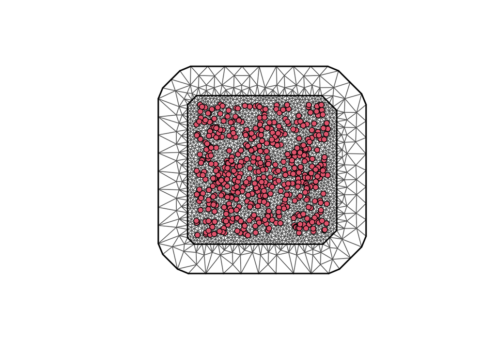

Triangulation of the study area [0,1]x[0,1], the red dots represent the data points locations

```r
par(mfrow = c(1,1))
plot(mesh)
points(loc, pch = 21, bg = 2)
```

Now we have to simulate our continuous spatial random effect, it depends on two parameters: the range $r$ and the marginal variance $\sigma_0^2$. The range is the distance at which the correlation of two points is around 0.13. The marginal variance is the marginal variance. We will set the range $r$ equal to a fifth of the size of the study area and $\sigma^2_0 = 1$. We pass the parameters to INLA using a different parametrization.

```r
# starting parametrization
size <- min(c(diff(range(mesh$loc[, 1])), diff(range(mesh$loc[, 2]))))
range <- size/5
sigma0 = 1

# new parametrization
kappa0 <- sqrt(8)/range
tau0 <- 1/(sqrt(4 * pi) * kappa0 * sigma0)

# create an spde object
spde <- inla.spde2.matern(mesh, B.tau = cbind(log(tau0), -1, +1),
                          B.kappa = cbind(log(kappa0), 0, -1))
```

It remains only to simulate the random effect. To do that we simulate from a **Gaussian Markow random field**, each component is related to a triangle and the precision Matrix $Q$ is defined through a Matérn covariance function. The INLA package helps us to retrieve the precision matrix $Q$

```r
Q = inla.spde.precision(spde, theta = c(0,0))
# the number of elements of Q is the square of the number of triangles
dim(Q)
```

```
## [1] 2294 2294
```

Let us simulate

```r
sample = inla.qsample(n = 2, Q, seed = 123)
```

Now we have a sample in which each element is related to a triangle and we need the values of the effect on the data points locations. To pass from the mesh locations to the data locations we need a matrix $A$ such that:

$$u(\boldsymbol{s}) = Au(\boldsymbol s')$$
Where $\boldsymbol s = \{s_1,...s_N\}$ are the data points locations and $\boldsymbol s' = \{s'_1,...,s'_{N'}\}$ are the mesh locations. The INLA package comes to help us again with the $\texttt{inla.spde.make.A()}$ function. This function takes as input a mesh and a set of location and computes the projection matrix $A$. Please pay attention: remember that working with Multinomial-Poisson transformation implies that for each location (multinomial observation) we have a number of Poisson observation equal to the number of alternatives. All of them are related to the same location, then, we have to replicate each location $3$ (number of alternatives) times. As before, we are considering a random effect acting only on the probability of the first alternative, hence, we have to select only the rows relatives to that one.

```r
# create A
A = inla.spde.make.A(mesh = mesh,
                      loc = cbind(rep(loc[,1], each = 3),
                                  rep(loc[,2], each = 3)))

# select rows relative to the first alternatives
A = A*rep(c(1,2,3) == 1, n)
```

The random effect will be the first column of the product between the projection matrix $A$ and the simulated **Gaussian Markov random field** on the mesh locations.

```r
random.effect = matrix(drop(A%*%sample[,2]), ncol = 3, byrow = T)[,1]
```

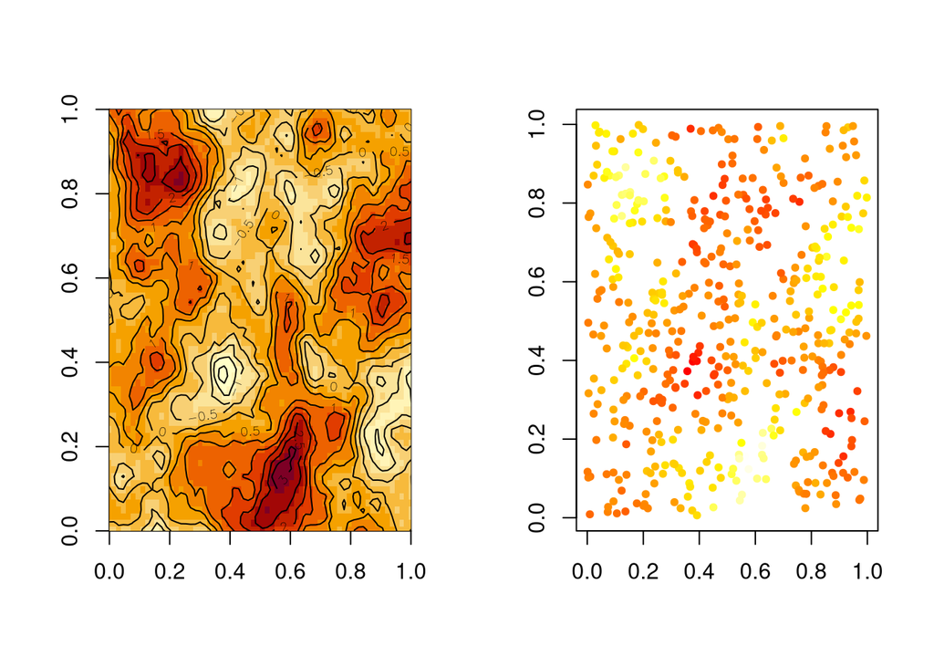

```r
par(mfrow = c(1,2))

# plot the continuos random effect
proj <- inla.mesh.projector(mesh, dims = c(100, 100))
sample_proj = inla.mesh.project(proj, field = sample[,2])
image(proj$x, proj$y, sample_proj , xlim = c(0,1), ylim = c(0,1),
      xlab = '',ylab = '')
contour(proj$x, proj$y, sample_proj, add = T)

# plot the projection on the sample locations
rbPal <- colorRampPalette(heat.colors(100))
Col <- rbPal(100)[as.numeric(cut(random.effect, breaks = 100))]
plot(loc, pch = 20, col = Col, xlab = '', ylab = '')
```

Now that we have a random effect defined on the locations we can go through the simulation of the multinomial data.

```r
# generate sample
Y.spde = Multinom.sample.rand(N = 100, random.effect)
# construct data set
df.spde = data.frame(cbind(Y.spde, X.A, X.B, X.C, W.A, W.B, W.C, Z))
Data.spde = Data.structure(df.spde)
round(head(Data.spde),3)
```

```
##    Y      X   W.A   W.B   W.C      Z phi alt.idx
## 1 84 28.599 0.179 0.000 0.000 19.549   1       1
## 2  7 32.893 0.000 0.488 0.000 19.549   1       2
## 3  9 39.004 0.000 0.000 0.321 19.549   1       3
## 4 18 29.425 0.693 0.000 0.000 19.017   2       1
## 5 14 31.522 0.000 1.237 0.000 19.017   2       2
## 6 68 38.960 0.000 0.000 1.574 19.017   2       3
```

To perform a Bayesian analysis with this kind of random effect with INLA we need to specify two more objects. This part is crucial to the success of our analysis, we shall never tire of repeating, the data is defined on a set of locations and the random effect is defined on another set of locations. From this incongruity derives the needing of an object that manages it for us. Again, INLA proves to be a good friend and provides us this object: the stack. The $\texttt{inla.stack()}$ function does the job, it mainly needs three thing:

- **data**: a *list* containing the variable subject of study and the offset if it is present.
- **effect**: a *list* containing the effects included in the model. The spatial random effect is represented by an index created with the function $\texttt{inla.spde.make.index()}$; the fixed effects are represented by the columns of the data frame containing the covariates.
- **A**: a *list* containing the projection matrices: one for the random effect and one for the fixed effects. The projection matrix for the random effect is the matrix $A$ created above. The projection matrix for the fixed effects is just $1$ because the covariates are recorded in the same locations of the data. Notice that if the covariates are recorded in different locations with respect the data, then we have to specify a different matrix.

```r
# index for the random effect
s_index <- inla.spde.make.index(name="spatial.field",
                                n.spde= spde$n.spde)

# stack object
stack = inla.stack(data = list(Y = Data.spde$Y),
                   effects = list(s_index, list(Data.spde[,2:8])),
                   A = list(A, 1))
```

We are at the end of our SPDE-journey and, finally, we are ready to fit the model. As always we need to specify a formula and an $\texttt{f()}$ function for the spatial random effect, in this case the index variable is the $\texttt{spatial.field}$ (element of the SPDE index created above). The model option is $\texttt{spde}$ and we need also to specify an additional option $\texttt{group = spatial.field.group}$ (another element of the SPDE index). After that, we can run the $\texttt{inla()}$ function and wait for the results. It will take some time especially if we work with a lot of data. Notice that the data is specified using the stack object. In particular we need to use the function $\texttt{inla.stack.data()}$. Furthermore, we need to specify also the projection matrix $A$. It is done in the $\texttt{control.predictor}$ option. This option requires a list containing an element $A$ and $\texttt{compute = T}$.

In the following code, we use a little trick to speed up the computations. This trick can be done only after a first fit of the model. It consists in specify values for the hyper-parameters and then use the option $\texttt{control.inla= list(int.strategy = "eb")}$. The last line of the chunk shows how to retrieve the hyper-parameters values. Without this adjustment, INLA takes around $2$ minutes to fit the model. Adding the starting value and using $\texttt{eb}$ strategy it takes around $7$ seconds. We strongly recommend doing this every time you have to fit a model multiple times trying little changes.

```r
formula.spde = Y ~ -1 + X + W.A + W.B + W.C +
  f(phi, initial = -10, fixed = T) +
  f(alt.idx, Z, fixed = T, constr = T) +
  f(spatial.field, model = spde, group = spatial.field.group)

init = c(-0.008, -0.093)
model.spde <- inla(formula.spde,
                   data=inla.stack.data(stack, spde = spde),
                   family="poisson",
                   control.predictor=list(A = inla.stack.A(stack), compute=TRUE),
                   control.inla= list(int.strategy = "eb"),
                   control.mode=list(restart=T, theta=init))

round(model.spde$internal.summary.hyperpar$mode, 3)
```

```
## [1]  0.056 -0.004
```

```r
# estimates on the mesh locations
spde.mesh.est = model.spde$summary.random$spatial.field$`0.5quant`
# estimates on the data locations
spde.loc.est = matrix(drop(A%*%spde.mesh.est),
                 ncol=3, byrow=TRUE)[,1]
# Mean Square Error
mean((spde.loc.est - random.effect)^2)
```

```
## [1] 0.05967029
```

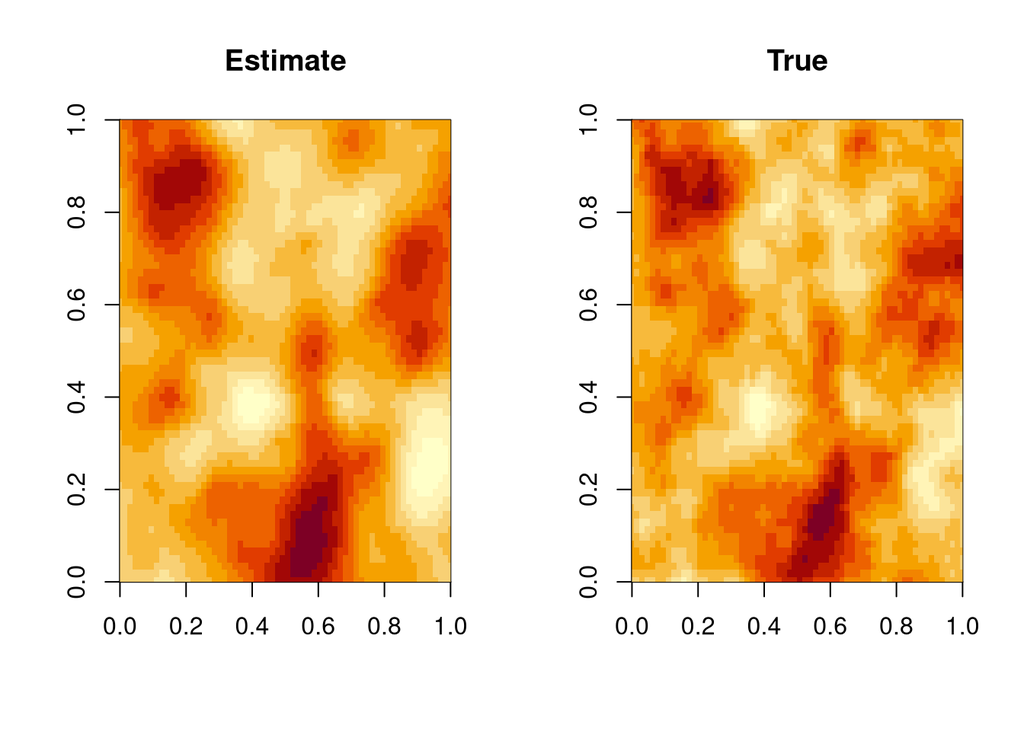

Recostruction of the spatial random field

```r
par(mfrow = c(1,2))

# plot the estimates
output_proj = inla.mesh.project(proj, field = spde.mesh.est)
image(proj$x, proj$y, output_proj , xlim = c(0,1), ylim = c(0,1),
      xlab = '',ylab = '', main = "Estimate")

# plot the true one
sample_proj = inla.mesh.project(proj, field = sample[,2])
image(proj$x, proj$y, sample_proj , xlim = c(0,1), ylim = c(0,1),
      xlab = '',ylab = '', main = "True")
```

### Yogurt Data

This is the last section of the tutorial; here we analyze the Yogurt Data studied in the literature on Multinomial models. The first to introduce it was Jain in 1994 (Janin, Vilcassim, and Chintagunta (1994)), the same results are obtained also by Lee, Green, and Ryan (2017) and Chen and Kuo (2001). In the first part of this section, we implement the model used in literature and in the second we propose some modification to the model.

#### Model

The data is composed of 2412 observations, each of them represents a choice situation in which a customer choose between four yogurt brands: yoplait, dannon, hiland, weight. The covariates are two alternative specific variables: price (continuous) and feat (Boolean). The latter indicates the presence of a feature advertisement on the newspapers. The data includes repeated choices for each individual. The data is included in the $\texttt{mlogit}$ package. The starting model is the following:

$$V_{ij} = \alpha_j + \beta_1 P_{ij} + \beta_2 F_{ij}$$
Where $i$ stands for the choice situation and not the customer. $P_{ij}$ stands for the price of brand $j$ in choice situation $i$ and $F_{ij}$ indicates the presence of a feature advertisement. Translating it into Poisson’s terms the model becomes:
$$Y_{ij} \sim \text{Poisson}(\lambda_{ij})$$
$$\log(\lambda_{ij}) = \phi_i + \alpha_j + \beta_1 P_{ij} + \beta_2 F_{ij}$$

Where $\alpha_j$ represents an intercept that depends on the yogurt brand. In this model, there are only alternative specific variables with generic coefficients. As you can see $\boldsymbol\beta = \{ \beta_1, \beta_2\}$ is the same for each choice situation and for each alternative. Hence, the data will be in *long* format. The original data is in *wide* format and looks like this

```r
data("Yogurt")
head(Yogurt)
```

```
##   id feat.yoplait feat.dannon feat.hiland feat.weight price.yoplait
## 1  1            0           0           0           0          10.8
## 2  1            0           0           0           0          10.8
## 3  1            0           0           0           0          10.8
## 4  1            0           0           0           0          10.8
## 5  1            0           0           0           0          12.5
## 6  1            0           0           0           0          10.8
##   price.dannon price.hiland price.weight choice
## 1          8.1          6.1          7.9 weight
## 2          9.8          6.4          7.5 dannon
## 3          9.8          6.1          8.6 dannon
## 4          9.8          6.1          8.6 dannon
## 5          9.8          4.9          7.9 dannon
## 6          9.2          5.0          7.9 dannon
```

Instead, the data that we are going to use is in this format:

```r
head(Data)
```

```
##   Y price feat cust.id phi alpha.idx
## 1 0 0.108    0       1   1   yoplait
## 2 0 0.081    0       1   1    dannon
## 3 0 0.061    0       1   1    hiland
## 4 1 0.079    0       1   1    weight
## 5 0 0.108    0       1   2   yoplait
## 6 1 0.098    0       1   2    dannon
```

The formula in this situation is straightforward

```r
formula = Y ~ -1 + price + feat + alpha.idx +
  f(phi, initial = -10, fixed = T)

model = inla(formula, data = Data, family = 'Poisson',
    control.inla=list(int.strategy="eb"))
```

These are the results and you can check the literature and see that they are almost the same.

```r
results = model$summary.fixed[,1:5]
rownames(results) = c("price", "feat", "dannon", "hiland", "weight", "yoplait")
round(results,3)
```

```
##            mean    sd 0.025quant 0.5quant 0.975quant
## price   -36.527 2.423    -41.276  -36.527    -31.778
## feat      0.493 0.120      0.258    0.493      0.728
## dannon    1.311 2.974     -4.518    1.311      7.140
## hiland   -2.407 2.973     -8.233   -2.407      3.419
## weight    0.670 2.974     -5.159    0.670      6.498
## yoplait   2.042 2.979     -3.796    2.042      7.880
```

Now that we have verified the correctness of our approach retrieving the literature results, we can do something more interesting. Think about the price, in the previous model the coefficient is unique no matter what the price is. We can suppose that lower prices encourage the purchase and, instead, that high prices discourage it. To check this hypothesis we divide the price classes and then we look for a different coefficient for each of them. Just to make the story more interesting we also suppose that the relation between the outcome and the price is non-linear. We can express this behavior fitting a random walk of order 1 on the price. In this way the coefficient $\beta_1$ depends on the price level, it becomes $\beta_1(P_{ij})$. The model is the following:

$$\log(\lambda_{ij}) = \phi_i + \alpha_j + P_{ij}\beta_1(P_{ij}) + \beta_2
F_{ij}$$

```r
Data$price.class = inla.group(Data$price, n = 12, method = "cut")

formula.price = Y ~ -1 + feat + alpha.idx +
  f(price.class, model = "rw1") +
  f(phi, initial = -10, fixed = T)

model.price = inla(formula.price, data = Data, family = 'Poisson',
    control.inla=list(int.strategy="eb"))

res = model.price$summary.fixed[,1:5]
rownames(res) = c('feat', 'dannon','hiland','weight','yoplait')
round(model.price$summary.random$price.class[,1:5],3)
```

```
##       ID   mean    sd 0.025quant 0.5quant
## 1  0.008  3.687 0.721      2.273    3.687
## 2  0.025  3.042 0.283      2.489    3.042
## 3  0.050  0.736 0.238      0.269    0.736
## 4  0.061  0.321 0.215     -0.100    0.321
## 5  0.079  0.427 0.209      0.018    0.427
## 6  0.086 -0.056 0.206     -0.461   -0.056
## 7  0.108 -0.894 0.212     -1.310   -0.894
## 8  0.122 -1.339 0.213     -1.757   -1.339
## 9  0.132 -2.445 0.474     -3.373   -2.445
## 10 0.193 -3.480 1.307     -6.042   -3.480
```

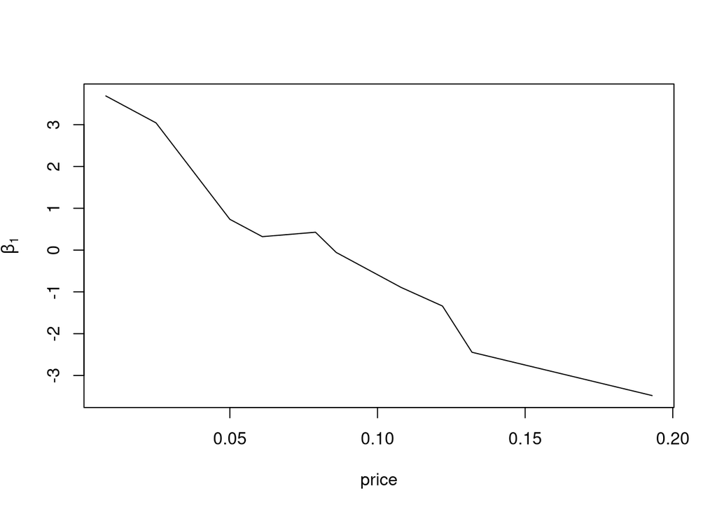

Relation between the coefficient and the price level

```r
plot(model.price$summary.random$price.class$ID,
     model.price$summary.random$price.class$mean, type = 'l',
     ylab = expression(beta[1]),
     xlab = 'price')
```

Another modification to the standard model that we can consider is about the covariates representing the presence of a feature advertisement. Here, we can consider an alternative specific coefficient. This choice materializes the following intuition: different brands have different advertisers and their advertising campaigns may have a different impact on the market. To consider the $\texttt{feat}$ covariate as related to an alternative specific coefficient we have to change the format. The data should be like this

```
##   Y price feat.yoplait feat.dannon feat.hiland feat.weight cust.id phi
## 1 0 0.108            0          NA          NA          NA       1   1
## 2 0 0.081           NA           0          NA          NA       1   1
## 3 0 0.061           NA          NA           0          NA       1   1
## 4 1 0.079           NA          NA          NA           0       1   1
## 5 0 0.108            0          NA          NA          NA       1   2
## 6 1 0.098           NA           0          NA          NA       1   2
##   alpha.idx
## 1   yoplait
## 2    dannon
## 3    hiland
## 4    weight
## 5   yoplait
## 6    dannon
```

The corresponding model is:
$$\log(\lambda_{ij}) = \phi_i + \alpha_j + \beta_1P_{ij} + \beta_{2j}
F_{ij}$$

```r
formula.feat = Y ~ -1 + price + feat.yoplait + feat.dannon +
  feat.hiland + feat.weight + alpha.idx +
  f(phi, initial = -10, fixed = T)


model.feat = inla(formula.feat, data = Data, family = 'Poisson',
    control.inla=list(int.strategy="eb"))
```

The results about the price and $\alpha_j$’s are almost the same that we found in the standard model. Then we show just the results relative to the feature advertisement.

```r
model.feat$summary.fixed[2:5, 1:5]
```

```
##                     mean        sd 0.025quant    0.5quant 0.975quant
## feat.yoplait  0.48935371 0.1919299  0.1131780  0.48935371  0.8655294
## feat.dannon  -0.01229097 0.2301912 -0.4634574 -0.01229097  0.4388754
## feat.hiland   1.95753629 0.3023411  1.3649586  1.95753629  2.5501140
## feat.weight   0.33150885 0.2401815 -0.1392382  0.33150885  0.8022559
```

From these results, it seems that the advertising campaign of hiland has a great impact on the choice compared with the other. On the other hand, maybe dannon has to review its advertising group. Just one problem, in our dataset hiland has been chosen only the $2\%$ of the times. This means that the above results could be due to over-fitting but going deeper is not in our purposes.

### Conclusion

Just few words to conclude this tutorial. As you have seen the Multinomial-Poisson transformation combined with INLA is an amazing combination and it allows us to implement complex models in a reasonable computational time. We hope that the reader appreciates this tutorial and that it is the beginning of a lasting friendship with INLA. For any question feel free to send an e-mail to [someone] or to write a post on the https://groups.google.com/forum/#!forum/r-inla-discussion-group.

## References

Auguie, Baptiste. 2017. *gridExtra: Miscellaneous Functions for "Grid" Graphics*. https://CRAN.R-project.org/package=gridExtra.

Baker, Stuart G. 1994. “The Multinomial-Poisson Transformation.” *The Statistician*, 495–504.

Besag, Julian. 1974. “Spatial Interaction and the Statistical Analysis of Lattice Systems.” *Journal of the Royal Statistical Society. Series B (Methodological)*, 192–236.

Blangiardo, Marta, and Michela Cameletti. 2015. *Spatial and Spatio-Temporal Bayesian Models with r-INLA*. John Wiley & Sons.

Chen, Zhen, and Lynn Kuo. 2001. “A Note on the Estimation of the Multinomial Logit Model with Random Effects.” *The American Statistician* 55 (2): 89–95.

Croissant, Yves et al. 2012. “Estimation of Multinomial Logit Models in r: The Mlogit Packages.” *R Package Version 0.2-2. URL: Http://Cran. R-Project. Org/Web/Packages/Mlogit/Vignettes/Mlogit. Pdf*.

Croissant, Yves. 2013. *Mlogit: Multinomial Logit Model*. https://CRAN.R-project.org/package=mlogit.

De Berg, Mark, Marc Van Kreveld, Mark Overmars, and Otfried Cheong Schwarzkopf. 2000. “Computational Geometry.” In *Computational Geometry*, 1–17. Springer.

Genz, Alan, and Frank Bretz. 2009. *Computation of Multivariate Normal and t Probabilities*. Lecture Notes in Statistics. Heidelberg: Springer-Verlag.

Janin, Dipak C, Naufel J Vilcassim, and Pradeep K Chintagunta. 1994. “A Random-Coefficients Logit Brand-Choice Model Applied to Panel Data.” *Journal of Business & Economic Statistics* 12 (3): 317–28.

Krainski, Elias T, Finn Lindgren, Daniel Simpson, and Havard Rue. 2017. “The r-INLA Tutorial on SPDE Models Warning: Work in Progress... Suggestions to Elias@ r-Inla. Org Are Welcome.”

Lee, Jarod YL, Peter J Green, and Louise M Ryan. 2017. “On the" Poisson Trick" and Its Extensions for Fitting Multinomial Regression Models.” *arXiv Preprint arXiv:1707.08538*.

Lindgren, Finn, Håvard Rue, and Johan Lindström. 2011. “An Explicit Link Between Gaussian Fields and Gaussian Markov Random Fields: The Stochastic Partial Differential Equation Approach.” *Journal of the Royal Statistical Society: Series B (Statistical Methodology)* 73 (4): 423–98.

Pebesma, Edzer. 2018. “Simple Features for R: Standardized Support for Spatial Vector Data.” *The R Journal* 10 (1): 439–46. https://doi.org/10.32614/RJ-2018-009.

Pebesma, Edzer J., and Roger S. Bivand. 2005. “Classes and Methods for Spatial Data in R.” *R News* 5 (2): 9–13. https://CRAN.R-project.org/doc/Rnews/.

Richards, Francis SG. 1961. “A Method of Maximum-Likelihood Estimation.” *Journal of the Royal Statistical Society. Series B (Methodological)*, 469–75.

Rue, Havard, and Leonhard Held. 2005. *Gaussian Markov Random Fields: Theory and Applications*. CRC press.

Rue, Håvard, Sara Martino, and Nicolas Chopin. 2009. “Approximate Bayesian Inference for Latent Gaussian Models by Using Integrated Nested Laplace Approximations.” *Journal of the Royal Statistical Society: Series b (Statistical Methodology)* 71 (2): 319–92.

Turner, Rolf. 2017. *Deldir: Delaunay Triangulation and Dirichlet (Voronoi) Tessellation*. https://CRAN.R-project.org/package=deldir.

Venables, William N, and Brian D Ripley. 2013. *Modern Applied Statistics with s-PLUS*. Springer Science & Business Media.